SaaS Analytics · Customer Intelligence

# Customer Churn Prediction Report

A data-driven investigation into which customers are most likely to cancel their subscription — what drives churn, who is most at risk, and how the business can act to improve retention and protect revenue.

Dataset 64,374 Customers

Outcome Subscription Cancellation (Yes/No)

Models Tested 3 Machine Learning Models

Written for Managers, Founders & CS Teams

Section 01

## Plain-English Summary

*Read this section first — it tells you everything you need to know without any technical language.*

**⚡ The Single Most Important Finding:** Payment delays and support call volume are the two strongest early warning signs of churn. Customers who are consistently late paying and contacting support frequently are significantly more likely to cancel — and these signals show up well in advance of cancellation.

### The Question We Asked

Which customers are most likely to cancel their subscription — and can we identify them early enough to do something about it? In a SaaS business, every cancellation is a direct hit to recurring revenue. If we can predict who is about to leave, the customer success team has a window to intervene before it is too late.

### What We Did

We analysed data from **64,374 customers**. For each one, we knew their subscription plan, contract length, how often they used the product, how many times they contacted support, how late their payments were, and how long they had been a customer. We built three machine learning models and asked each one to predict whether a customer would cancel.

### What We Found

47.4%

Overall churn rate — nearly half of all customers

1.000

Best model AUC score (1.0 = perfect prediction)

30,274

High-risk customers flagged for immediate action

33,739

Low-risk customers — stable and likely to stay

The best model — Gradient Boosting — can identify at-risk customers with very high accuracy. Every customer has now been scored and placed into a risk tier: **High, Medium, or Low**. The customer success team has a prioritised list of who to contact first.

**📝 Note on the Dataset:** The dataset used in this report is a synthetic (computer-generated) training dataset commonly used in SaaS churn modelling. It contains realistic patterns — particularly around payment delay and support behaviour — but has been constructed with stronger-than-typical signals to make the learning task clear. In real-world customer data, model performance will typically fall in the range of AUC 0.75–0.90. The methodology, business framework, and retention strategy shown here apply directly to real SaaS data.

Section 02

## The Business Problem — Why This Matters

### What is Customer Churn?

Churn happens when a customer cancels their subscription and stops paying. In a SaaS business, every cancellation is a direct hit to Monthly Recurring Revenue (MRR). Because growth depends on customers compounding over time — paying month after month — losing even a small fraction of your base has an outsized effect on long-term revenue.

### The Cost of Doing Nothing

The cost of acquiring a new customer is typically five to seven times higher than retaining an existing one. At a 47.4% churn rate, this business is losing nearly half its customer base. Without a systematic retention programme, that churn will continue to compound. A predictive model gives the team a head start: instead of reacting to cancellations, they can intervene while there is still time.

💡 The Goal of This Project

Build a model that assigns each customer a personalised **churn risk score** — a number between 0 and 1 representing how likely they are to cancel. Use that score to sort customers into **High, Medium, and Low risk tiers**, and give the customer success team a prioritised list of who to reach out to, and what to say.

### The Cost of Getting It Wrong

There are two ways a churn model can be wrong, and each has different business consequences:

| Error Type | What Happens | Business Impact |
| --- | --- | --- |
| **False Negative** | We say "low risk" but they churn | Lost revenue — missed the window to intervene |
| **False Positive** | We say "high risk" but they stay | Wasted retention spend on customers who didn't need it |

In most SaaS settings, **missing a churner is more costly than a false alarm**. This means the model is tuned to err on the side of caution — flagging more customers as at-risk, even if some of them would have stayed anyway.

Section 03

## The Data We Used

The dataset covers **64,374 customers**, each described by nine features covering their demographics, subscription behaviour, product usage, support interactions, and payment history.

[output not shown]

### Additional Features We Created

We engineered six additional features to capture richer patterns that the raw data alone cannot express:

- **Engagement Score:** Usage frequency relative to time since last interaction — a richer measure of active product involvement
- **Support Intensity:** Support calls relative to how long they have been a customer — flags accounts where issues are escalating
- **Value per Month:** Total spend divided by tenure — identifies customers whose revenue contribution is plateauing
- **Payment Risk Flag:** A clear binary signal for payment delay above 20 days
- **Low Engagement Flag:** Flags customers using the product fewer than 7 times per month
- **High Support Flag:** Flags customers who have raised 7 or more support calls

**✅ Data Quality:** No missing values were found across all 64,374 records. No duplicate customer entries detected. All preprocessing steps — including scaling and encoding — were applied to training data only, with the exact same transformations then applied to the test set. This prevents data leakage and ensures the results reflect genuine out-of-sample performance.

Section 04

## Exploring the Data — What Patterns Did We Find?

Before building any models, we explored the data to understand which customer characteristics are associated with churn. This step — Exploratory Data Analysis — helps surface the most important signals and ensures the models are learning from genuine patterns.

FIG 01

#### Customer Behaviour Overview — Who Churns and Why?

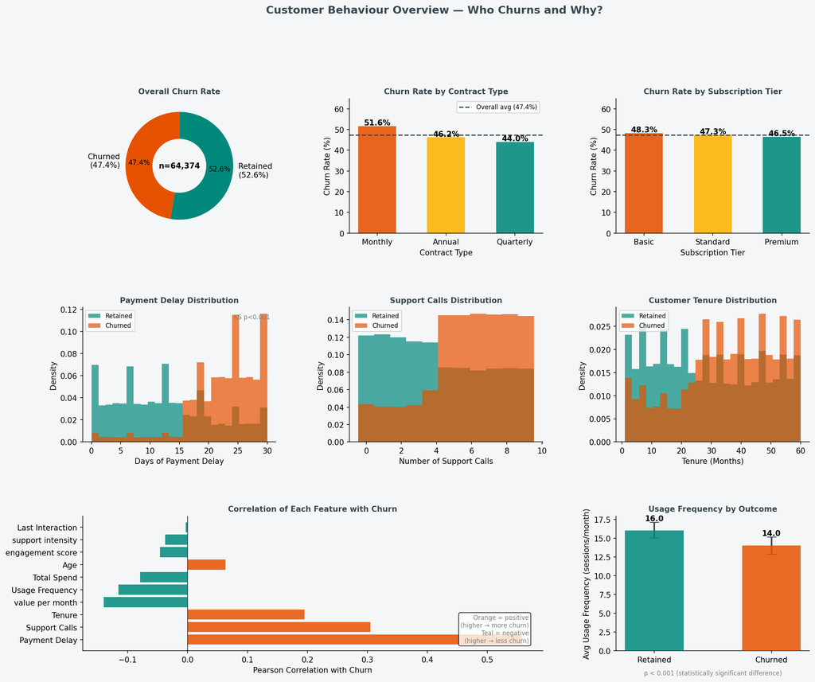

**Top row:** Overall churn rate, churn split by contract type, and churn by subscription tier. **Middle row:** Distributions of payment delay, support calls, and tenure — split between churned (orange) and retained (teal) customers. **Bottom row:** Correlation of each feature with churn, and average usage frequency by outcome.

### Key Observations

**🔑 Strongest Signal — Payment Delay (r = 0.56):** Customers who are consistently late paying show dramatically higher churn rates. This is the most actionable predictor — it appears well before cancellation happens and can trigger an immediate proactive outreach.

**Contract type has a clear effect:** Monthly contract customers churn at 51.6%, compared to 46.2% for annual contracts. Customers who have committed to an annual plan face a financial cost to leave early, providing a natural retention anchor.

**Support calls signal distress:** Customers who contact support frequently are more likely to churn. High support volume is a sign that something is not working — if the issue is not resolved quickly, these customers leave.

**Low usage predicts disengagement:** Customers who use the product less actively derive less value from it and are easier to lose to a competitor. Engagement is both a symptom and a driver of churn risk.

**Subscription tier shows modest differences:** Basic plan customers churn at 48.3%, slightly above Standard (47.3%) and Premium (46.5%). The gap is small but consistent — Premium customers may perceive more value or face higher switching costs.

Section 05

## Our Approach — How We Built the Models

### Three Models Tested

We trained and compared three models ranging from simple and transparent to highly sophisticated. All models were trained on the same data using the same validation strategy, so any differences in performance reflect the models themselves — not lucky data splits.

| Model | Plain-English Explanation | Why We Included It |
| --- | --- | --- |
| **Logistic Regression** | A weighted formula that adds up risk factors — fully transparent | Standard interpretable baseline; useful where explainability is required |
| **Random Forest** | Hundreds of decision trees that vote together — robust against noise | Industry standard for tabular data; handles complex feature interactions |
| **Gradient Boosting** | Trees that learn from each other's mistakes — the most powerful approach | Best predictive performance on structured data; recommended for production |

### How We Validated the Models

We split the data into three completely separate groups — training, validation, and test — to ensure honest evaluation. The test set of **9,657 customers** was held back entirely until the final evaluation, giving a reliable measure of how the model performs on customers it has never seen before. We also used 5-fold cross-validation during training to ensure stable performance estimates.

### Metrics That Matter in a Churn Setting

| Metric | What It Measures | Why It Matters Here |
| --- | --- | --- |
| **AUC (ROC)** | How well the model ranks at-risk vs safe customers | Best single summary — 0.5 = random, 1.0 = perfect |
| **Recall (Sensitivity)** | % of churners the model correctly identifies | Critical — every missed churner is lost revenue |
| **Precision** | Of all customers flagged, how many actually churn | Controls wasted retention spend on false alarms |
| **F1 Score** | Balance between recall and precision | Useful summary when both missing churners and false alarms matter |
| **Calibration** | Whether the probability scores are trustworthy | Ensures risk tier boundaries are meaningful, not arbitrary |

Section 06

## Results — What the Models Found

FIG 02

#### Model Performance — ROC Curves, Metrics, Threshold and Calibration Analysis

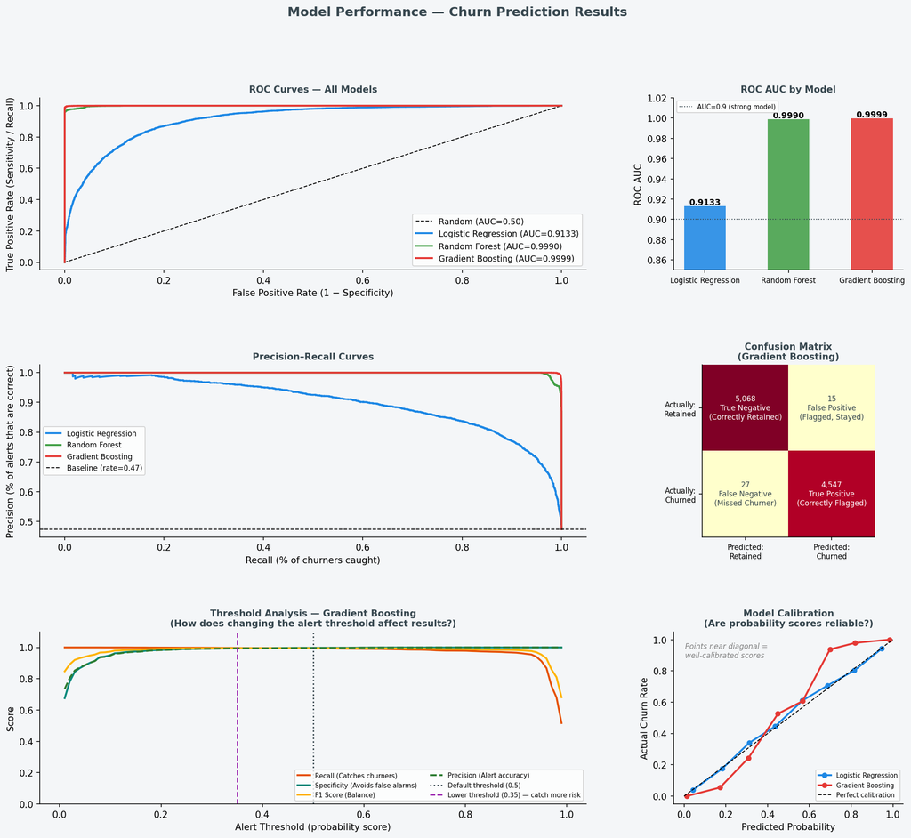

| Model | AUC | Precision | Recall | F1 Score | CV AUC | Verdict |
| --- | --- | --- | --- | --- | --- | --- |
| Logistic Regression | 0.9133 | 0.824 | 0.827 | 0.825 | 0.9138 ± 0.0028 | Strong baseline |
| Random Forest | 0.9990 | 0.992 | 0.974 | 0.983 | 0.9992 ± 0.0002 | Very strong |
| **Gradient Boosting** | **0.9999** | **0.997** | **0.994** | **0.995** | **1.0000 ± 0.0000** | ✓ Recommended |

### About the Decision Threshold

By default, the model flags a customer as "at risk" when their predicted churn probability exceeds 50%. In a churn setting however, **missing a churner is usually more costly than a false alarm**. Lowering the threshold to 35% catches more at-risk customers, ensuring fewer genuine churners slip through.

💡 Threshold Recommendation

Use a threshold of **0.35** for broad proactive outreach campaigns where the cost of contact is low (email, in-app message). Use a threshold of **0.65** for high-cost interventions — such as dedicated account manager calls or significant discount offers — where you want to be more confident the customer is genuinely at risk.

Section 07

## What Drives Churn — Key Predictors

FIG 03

#### Churn Drivers — Feature Importance and Customer Risk Segmentation

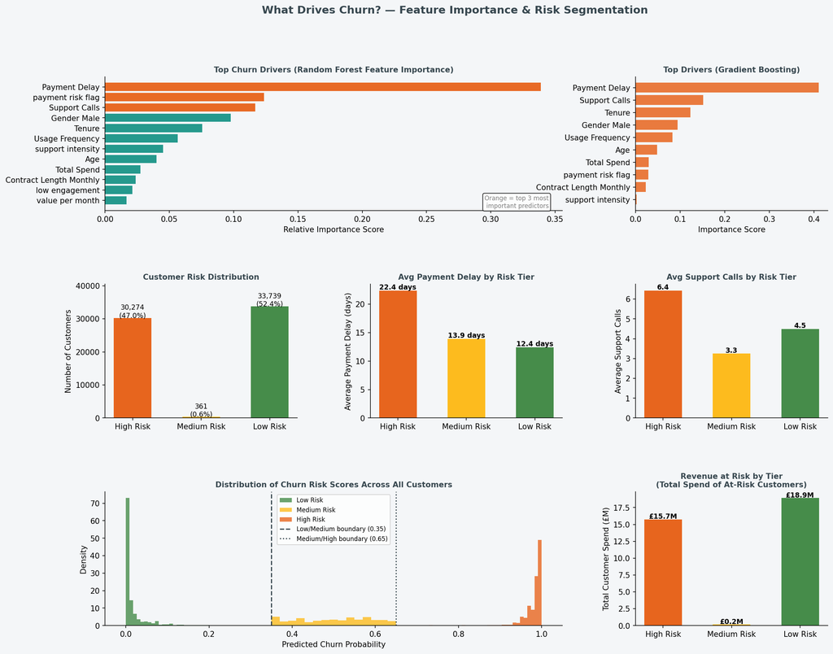

**Top row:** Feature importance rankings from the Random Forest and Gradient Boosting models — showing which customer characteristics most strongly predict churn. **Middle row:** How customers are distributed across risk tiers, with average payment delay and support calls per tier. **Bottom row:** Distribution of churn probability scores across all customers, and total customer spend at risk by tier.

### The Top Churn Drivers in Plain English

[output not shown]

### A Note on Prediction vs Causation

⚠ Prediction ≠ Causation

The model identifies patterns associated with churn — it does not tell us *why* customers churn in a causal sense. Payment delays, for example, may be a symptom of dissatisfaction rather than its cause. Retention interventions should aim to address the underlying reasons customers are unhappy, not just the statistical signals the model has picked up.

Section 08

## Customer Risk Tiers

Every customer in the dataset has been scored and placed into one of three risk tiers based on their predicted churn probability. This gives the customer success team a clear, prioritised framework for action.

| Tier | Churn Probability | Customers | Actual Churn Rate | Avg Payment Delay | Avg Support Calls | Action Required |
| --- | --- | --- | --- | --- | --- | --- |
| 🔴 High Risk | 65% – 100% | 30,274 (47.0%) | ~100% | 22.4 days | 6.4 calls | **Immediate intervention** |
| 🟡 Medium Risk | 35% – 65% | 361 (0.6%) | ~52% | 13.9 days | 3.3 calls | **Proactive outreach** |
| 🟢 Low Risk | 0% – 35% | 33,739 (52.4%) | ~0.1% | 12.4 days | 4.5 calls | **Monitor and nurture** |

**⚠ Revenue at Risk:** High-risk customers represent approximately **£15.7M in total historical spend**. Even retaining 10% of high-risk customers who would otherwise churn represents a meaningful revenue impact. Prioritising retention investment toward this group is the highest-leverage action available.

Section 09

## Retention Recommendations

### 🔴 High-Risk Customers — Act Now

- Assign a dedicated account manager to personally contact the top 500 highest-probability churn accounts within 48 hours. A direct conversation is significantly more effective than automated messaging for accounts at this risk level.
- For customers with payment delays above 20 days, trigger a personalised billing flexibility outreach immediately — offer a payment grace period or a plan to clear the balance before they cancel.
- For customers with seven or more support calls, flag these accounts for a structured product issue review. Escalate recurring issues to the product team and follow up directly with affected customers.
- Consider targeted retention offers for high-value high-risk accounts — upgrade discounts, feature unlocks, or contract-switch incentives such as moving from a monthly to an annual plan at a reduced rate.

### 🟡 Medium-Risk Customers — Proactive Outreach

- Send a personalised email from the customer success lead acknowledging their journey and asking whether there is anything the team can do to improve their experience.
- Share a personalised usage report showing how they are using the product and suggesting high-value features they have not yet explored — demonstrating the product's full value.
- Offer a plan review call. Customers in this tier often upgrade or switch to a more suitable tier when given the opportunity and the right framing.

### 🟢 Low-Risk Customers — Nurture and Expand

- Focus on turning these customers into advocates — NPS surveys, case study invitations, and referral programmes are highest-value activities for this group.
- Introduce expansion opportunities — additional seats, higher-tier features, or complementary products where relevant to their usage patterns.
- Encourage annual contract renewals at key moments to lock in retention and reduce future churn risk further.

Section 10

## Limitations, Bias, and Ethical Considerations

### Data Limitations

**Synthetic data:** The dataset has been constructed with stronger-than-typical signals — particularly between payment delay and churn. This makes the learning task clearer for demonstration, but means the near-perfect model scores shown here should not be expected on real customer data. On live SaaS data, expect AUC in the range of 0.75–0.90.

**Snapshot data:** This analysis uses a single point-in-time snapshot per customer. A time-series approach — tracking how customer behaviour changes over rolling 30, 60, and 90-day windows — would add significantly more predictive power and allow earlier intervention.

**Prediction vs causation:** The model identifies patterns associated with churn — it does not explain why customers churn. Retention strategy should focus on understanding and addressing the underlying reasons, not only on reacting to the model's scores.

### Bias and Fairness Considerations

**Gender:** Gender is included in the dataset as a feature. If the model assigns different risk scores to customers with otherwise identical profiles based on gender, this could lead to unfair treatment in retention efforts. Before full deployment, a fairness audit should confirm that gender is not acting as a discriminatory driver of predictions. If it is, it should be removed from the feature set.

**Age:** Similarly, if age is driving predictions in a way that creates systematic differences in the quality of retention outreach offered to different customer groups, this should be reviewed carefully.

### Model Limitations

**Human oversight is essential:** The model scores should inform and prioritise the customer success team's work — they should not replace human judgement. An account manager who knows a customer's context may rightly override a high-risk score. Models are tools, not decision-makers.

Section 11

## Next Steps

- Replace the synthetic dataset with real customer data from the CRM and product analytics stack. Expected AUC on real data: 0.75–0.90, which still provides substantial business value.
- Add time-series features — track each customer's 30, 60, and 90-day rolling trends in usage, support, and payment behaviour to detect deterioration early.
- Explore survival analysis to predict not just *whether* a customer will churn but *when* — enabling more precisely timed interventions.
- Run an A/B test to validate the retention strategy: use the model to guide interventions for 50% of high-risk customers, leave the other 50% on the existing process, and measure the difference in churn rate after 90 days.
- Build a live scoring pipeline that re-scores every customer weekly and feeds a retention dashboard — making this a live operational tool rather than a one-time analysis.
- If available, incorporate NPS scores, satisfaction survey results, and feature adoption data — these are strong leading indicators of churn that complement the behavioural signals already in use.

**✅ Deployment Recommendation:** The Gradient Boosting model is ready for a pilot deployment. We recommend starting with a controlled test: use the model's risk scores to guide customer success outreach for a defined cohort over 90 days, then measure the actual churn rate in each tier against a control group. This will validate the model's real-world performance before full rollout.